```python
import numpy as np #data analysis
import pandas as pd #data analysis

import matplotlib.pyplot as plt #data visualisation
%matplotlib inline
import seaborn as sns #data visualisation
import missingno as msno # Missing data-#data visualisation
from collections import Counter # Counting use capital C

#Data Preprossesing
from sklearn.model_selection import train_test_split
from sklearn.preprocessing import MinMaxScaler # to normalise my data in cases of outliers between 0 and 1

#classifier Libraries for Machine learning algorithm
from sklearn.linear_model import SGDClassifier
from sklearn.neighbors import KNeighborsClassifier
from sklearn.ensemble import RandomForestClassifier
from sklearn.linear_model import LogisticRegression

from sklearn.svm import LinearSVC, SVC
from sklearn.naive_bayes import GaussianNB
from sklearn.svm import SVC
from sklearn.tree import DecisionTreeClassifier
#pip install xgboost if not available
from xgboost import XGBClassifier

#Evaluation Metrics
from sklearn.metrics import accuracy_score, precision_score, recall_score, f1_score, roc_auc_score
from sklearn.metrics import confusion_matrix
```

```python
#load data set
df = pd.read_csv(r"C:\Users\22077\Downloads\Heart Disease.csv")
df.head()
```

|  | age | sex | cp | restbp | chol | fbs | restecg | mhrach | exang | oldpeak | slope | ca | thal | target |
| --- | --- | --- | --- | --- | --- | --- | --- | --- | --- | --- | --- | --- | --- | --- |
| 0 | 63 | 1 | 3 | 145 | 233 | 1 | 0 | 150 | 0 | 2.3 | 0 | 0 | 1 | 1 |
| 1 | 37 | 1 | 2 | 130 | 250 | 0 | 1 | 187 | 0 | 3.5 | 0 | 0 | 2 | 1 |
| 2 | 41 | 0 | 1 | 130 | 204 | 0 | 0 | 172 | 0 | 1.4 | 2 | 0 | 2 | 1 |
| 3 | 56 | 1 | 1 | 120 | 236 | 0 | 1 | 178 | 0 | 0.8 | 2 | 0 | 2 | 1 |
| 4 | 57 | 0 | 0 | 120 | 354 | 0 | 1 | 163 | 1 | 0.6 | 2 | 0 | 2 | 1 |

# Features in the dataset and meaning:

## target - have disease or not (I = yes, 0 =no).

```python
df.columns = ['age', 'sex', 'chest_pain_type', 'systolic_bp', 'Cholesterol', 'FBS', 'rest_ecg', 'max_hr', 'exercise_induced_angina', 'st_depression', 'st_slope', 'num_major_vessels', 'thalassemia', 'target']
```

```python
df.info()
```

```
<class 'pandas.core.frame.DataFrame'>
RangeIndex: 303 entries, 0 to 302
Data columns (total 14 columns):
 #   Column                   Non-Null Count  Dtype
---  ------                   --------------  -----
 0   age                      303 non-null    int64
 1   sex                      303 non-null    int64
 2   chest_pain_type          303 non-null    int64
 3   systolic_bp              303 non-null    int64
 4   Cholesterol              303 non-null    int64
 5   FBS                      303 non-null    int64
 6   rest_ecg                 303 non-null    int64
 7   max_hr                   303 non-null    int64
 8   exercise_induced_angina  303 non-null    int64
 9   st_depression            303 non-null    float64
 10  st_slope                 303 non-null    int64
 11  num_major_vessels        303 non-null    int64
 12  thalassemia              303 non-null    int64
 13  target                   303 non-null    int64
dtypes: float64(1), int64(13)
memory usage: 33.3 KB
```

```
age                        0
sex                        0
chest_pain_type            0
systolic_bp                0
Cholesterol                0
FBS                        0
rest_ecg                   0
max_hr                     0
exercise_induced_angina    0
st_depression              0
st_slope                   0
num_major_vessels          0
thalassemia                0
target                     0
dtype: int64
```

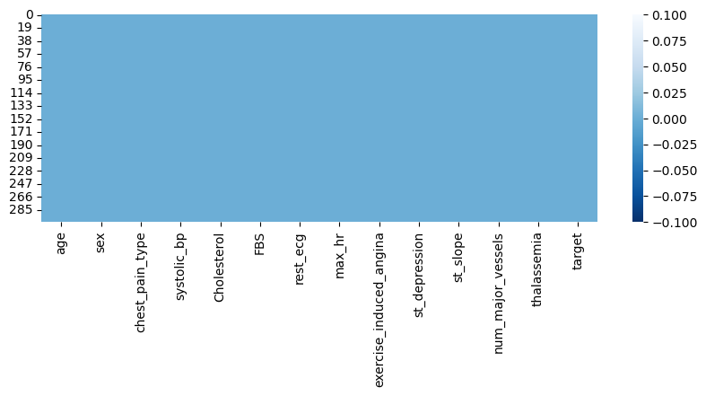

```python
df.isnull().sum() # you can also use df.isna().sum()
print (df.isnull().sum())
#visuliasing the missing data

plt.figure(figsize = (10,3))
sns.heatmap(df.isnull(), cbar = True, cmap = 'Blues_r')
```

```python
df['age'].value_counts() # shows the number of times each age values in the data set
```

```
58    19
57    17
54    16
59    14
52    13
51    12
62    11
60    11
44    11
56    11
64    10
41    10
63     9
67     9
65     8
```

[output cut: 27 more lines]

```python
df.describe()
```

|  | age | sex | chest_pain_type | systolic_bp | Cholesterol | FBS | rest_ecg | max_hr | exercise_induced_angina | st_depression | st_slope | num_major_vessels | thalassemia | target |
| --- | --- | --- | --- | --- | --- | --- | --- | --- | --- | --- | --- | --- | --- | --- |
| count | 303.000000 | 303.000000 | 303.000000 | 303.000000 | 303.000000 | 303.000000 | 303.000000 | 303.000000 | 303.000000 | 303.000000 | 303.000000 | 303.000000 | 303.000000 | 303.000000 |
| mean | 54.366337 | 0.683168 | 0.966997 | 131.623762 | 246.264026 | 0.148515 | 0.528053 | 149.646865 | 0.326733 | 1.039604 | 1.399340 | 0.729373 | 2.313531 | 0.544554 |
| std | 9.082101 | 0.466011 | 1.032052 | 17.538143 | 51.830751 | 0.356198 | 0.525860 | 22.905161 | 0.469794 | 1.161075 | 0.616226 | 1.022606 | 0.612277 | 0.498835 |
| min | 29.000000 | 0.000000 | 0.000000 | 94.000000 | 126.000000 | 0.000000 | 0.000000 | 71.000000 | 0.000000 | 0.000000 | 0.000000 | 0.000000 | 0.000000 | 0.000000 |
| 25% | 47.500000 | 0.000000 | 0.000000 | 120.000000 | 211.000000 | 0.000000 | 0.000000 | 133.500000 | 0.000000 | 0.000000 | 1.000000 | 0.000000 | 2.000000 | 0.000000 |
| 50% | 55.000000 | 1.000000 | 1.000000 | 130.000000 | 240.000000 | 0.000000 | 1.000000 | 153.000000 | 0.000000 | 0.800000 | 1.000000 | 0.000000 | 2.000000 | 1.000000 |
| 75% | 61.000000 | 1.000000 | 2.000000 | 140.000000 | 274.500000 | 0.000000 | 1.000000 | 166.000000 | 1.000000 | 1.600000 | 2.000000 | 1.000000 | 3.000000 | 1.000000 |
| max | 77.000000 | 1.000000 | 3.000000 | 200.000000 | 564.000000 | 1.000000 | 2.000000 | 202.000000 | 1.000000 | 6.200000 | 2.000000 | 4.000000 | 3.000000 | 1.000000 |

```python
## plotting the correlation or relationship between each parameter of the character or column
corr_matrix = df.corr()
```

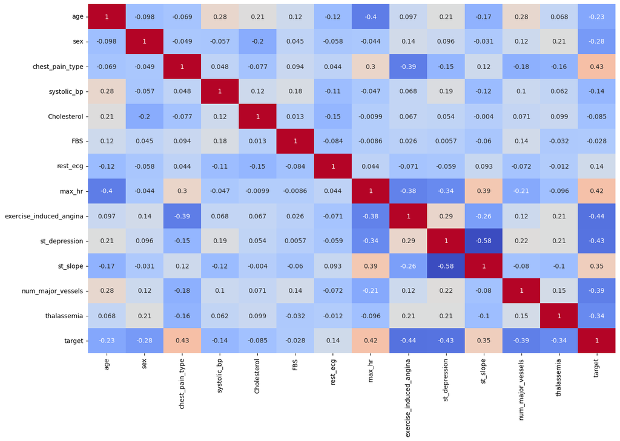

```python
## plotting the correlation or relationship between each parameter of the character or column

plt.figure(figsize = (15,10))


sns.heatmap(corr_matrix, cmap='coolwarm', annot=True, cbar=False)
```

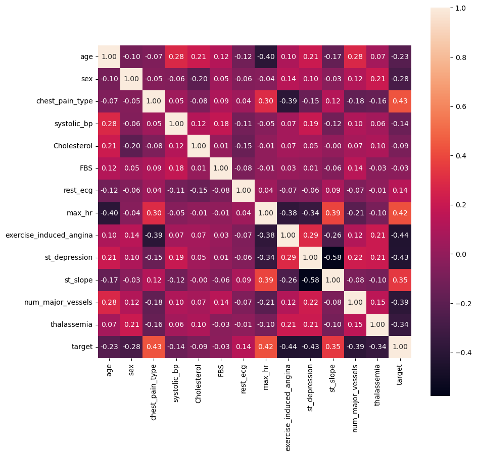

```python
plt.figure(figsize =(10,10))

sns.heatmap(corr_matrix, cbar=True, annot=True, square=True, fmt='.2f',annot_kws={'size':10})
```

###### # Checking on the correlation of each variable is significant. For example, there is a good correlation between st-slope, chest pain type and max heart rate

# Exploratory data analysis

## Univariate analysis

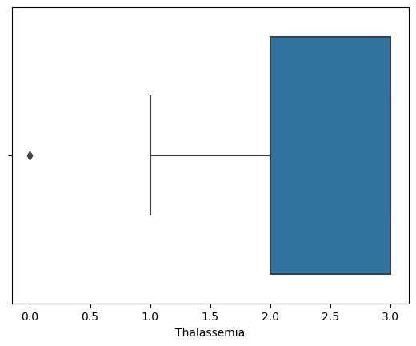

```python
# I am checking on the thalassemia, FBS, Cholesterol, systolic Bp and max hr columns for outliers

sns.boxplot(x=df['thalassemia'])
plt.xlabel('Thalassemia');
```

```python
df.columns
```

```
Index(['age', 'sex', 'chest_pain_type', 'systolic_bp', 'Cholesterol', 'FBS',
       'rest_ecg', 'max_hr', 'exercise_induced_angina', 'st_depression',
       'st_slope', 'num_major_vessels', 'thalassemia', 'target'],
      dtype='object')
```

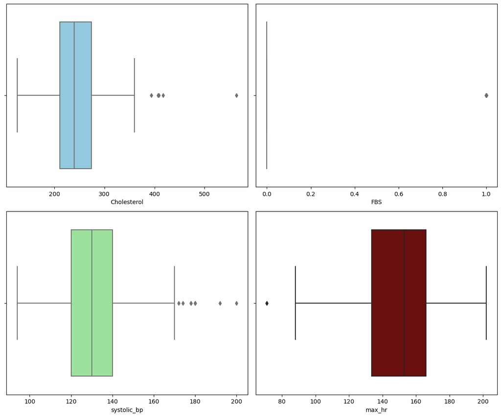

```python
# I am checking on the thalassemia, FBS, Cholesterol, systolic Bp and max hr columns for outliers

# Create a figure and axis objects for subplots
fig, axes = plt.subplots(nrows=2, ncols=2, figsize=(12, 10))

# Box plot for 'Cholesterol' with a specific color
sns.boxplot(x=df['Cholesterol'], ax=axes[0, 0], color='skyblue')
axes[0, 0].set_xlabel('Cholesterol')

# Box plot for 'FBS' with a different color
sns.boxplot(x=df['FBS'], ax=axes[0, 1], color='salmon')
axes[0, 1].set_xlabel('FBS')

# Box plot for 'systolic_bp' with another color
sns.boxplot(x=df['systolic_bp'], ax=axes[1, 0], color='lightgreen')
axes[1, 0].set_xlabel('systolic_bp')

# Box plot for 'max_hr' with a different color
sns.boxplot(x=df['max_hr'], ax=axes[1, 1], color='#780000')
axes[1, 1].set_xlabel('max_hr')

# Adjust layout to prevent overlapping labels
plt.tight_layout()

# Show the plots
plt.show()
```

##### in machine learning, you have to standardize your outliers because the AI will pay more attantion to higher figures and ity will affect the predictive analysis using machine learning

```python
# Data visualisation for age
# I will group the ages into four groups
# youths, adult, older adults, and elderly

def age_bracket(age):
    if age <=35:
        return "Youths(<35)"
    elif age <=55:
        return "Adults(<55)"
    elif age <= 65:
        return "Old Adults(<65)"
    else:
        return "Elderly(>65)"

df['age_bracket'] = df['age'].apply(age_bracket) # to change the name of the column to age_bracket from age
```

```
<function matplotlib.pyplot.title(label, fontdict=None, loc=None, pad=None, *, y=None, **kwargs)>
```

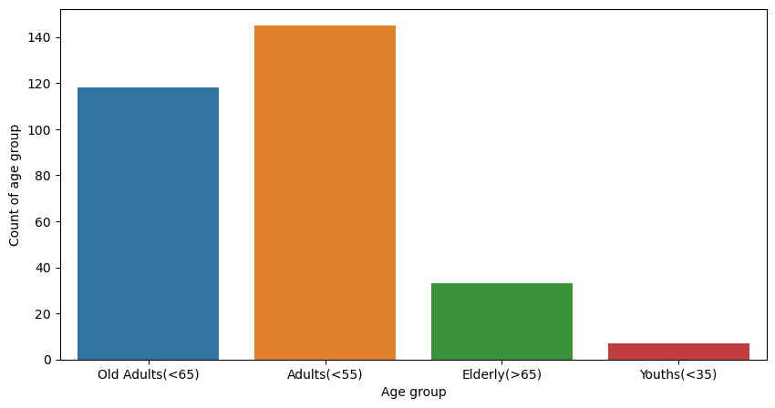

```python
plt.figure(figsize = (10,5))

sns.countplot(x='age_bracket', data=df)
plt.xlabel("Age group")
plt.ylabel('Count of age group')
plt.title
```

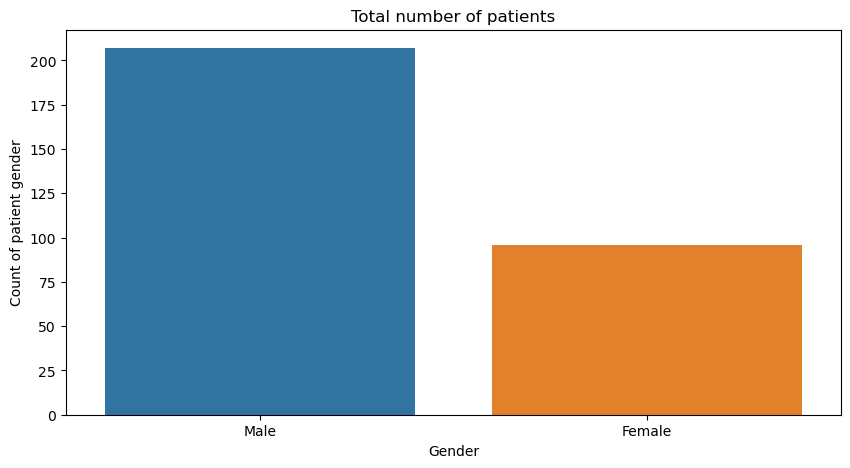

```python
def gender(sex):
    if sex == 1:
        return "Male"
    else:
        return "Female"

df['gender']=df['sex'].apply(gender)

plt.figure(figsize = (10,5))

sns.countplot(x='gender', data=df)
plt.xlabel("Gender")
plt.ylabel('Count of patient gender')
plt.title('Total number of patients')
plt.show()
```

More males than females

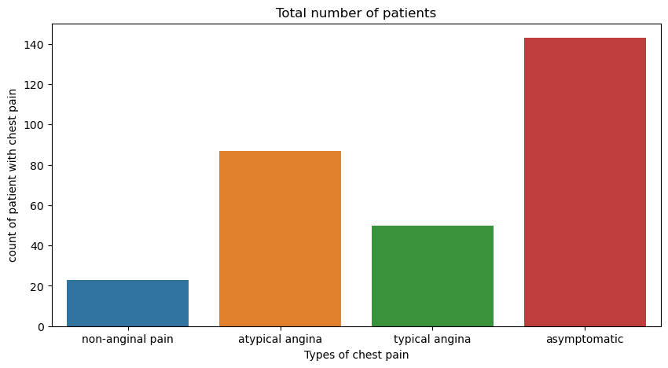

```python
# chest pain type

def chest_pain(cp):
    if cp == 1:
        return 'typical angina'
    elif cp == 2:
        return 'atypical angina'
    elif cp == 3:
        return 'non-anginal pain'
    else:
        return 'asymptomatic'

df['cp_cat'] = df['chest_pain_type'].apply(chest_pain)

plt.figure(figsize = (10,5))

sns.countplot(x='cp_cat', data=df)
plt.xlabel("Types of chest pain")
plt.ylabel('count of patient with chest pain')
plt.title('Total number of patients')
plt.show()
```

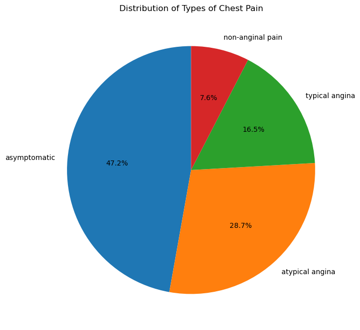

```python
# Calculate the counts for each type of chest pain
cp_counts = df['cp_cat'].value_counts()

# Calculate percentages for each type of chest pain
total_count = len(df['cp_cat'])
percentages = [(count / total_count) * 100 for count in cp_counts]

# Labels for the pie chart
labels = cp_counts.index

# Create the pie chart
plt.figure(figsize=(8, 8))
plt.pie(percentages, labels=labels, autopct='%.1f%%', startangle=90)

# Add a title
plt.title('Distribution of Types of Chest Pain')

# Display the pie chart
plt.show()
```

```
yes    165
no     138
Name: label, dtype: int64
```

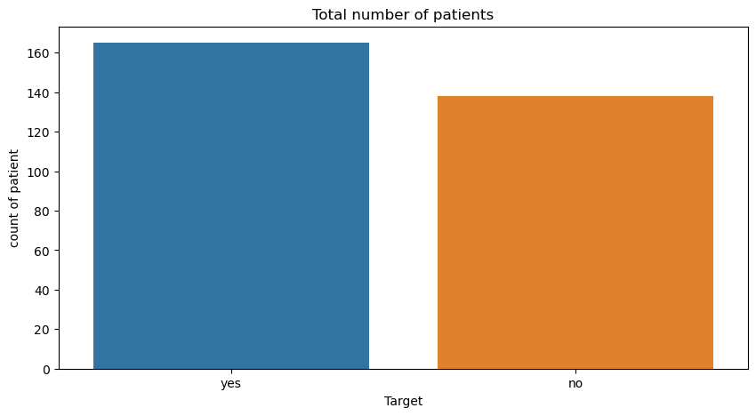

```python
# Target - have a disease or not (1=yes, 0=no)

def label(tg):
    if tg == 1:
        return 'yes'
    else:
        return 'no'

df['label'] = df['target'].apply(label)

print (df['label'].value_counts())

plt.figure(figsize = (10,5))

sns.countplot(x='label', data=df)
plt.xlabel("Target")
plt.ylabel('count of patient')
plt.title('Total number of patients')
plt.show()
```

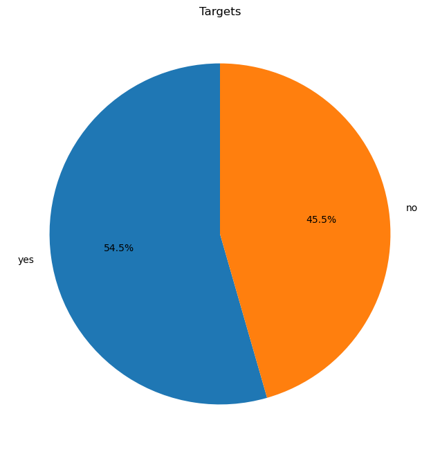

```python
# Calculate the counts for each target label
label_counts = df['label'].value_counts()

# Calculate percentages for each target label
total_count = len(df['label'])
percentages = [(count / total_count) * 100 for count in label_counts]

# Labels for the pie chart
labels = label_counts.index

# Create the pie chart
plt.figure(figsize=(8, 8))
plt.pie(percentages, labels=labels, autopct='%.1f%%', startangle=90)

# Add a title
plt.title('Targets')

# Display the pie chart
plt.show()
```

54.5 % have heart diseases

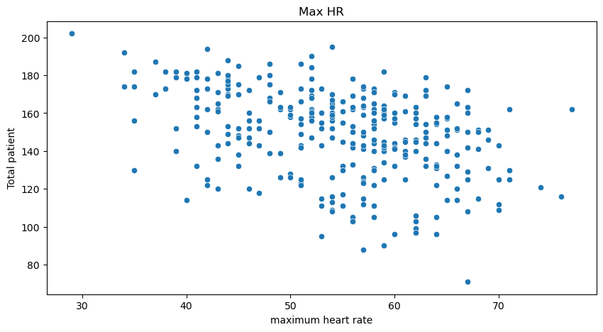

```python
# i want to visualise the resting BP using a scatter plot

plt.figure(figsize=(10,5))

sns.scatterplot(x='age', y= 'max_hr', data=df)
plt.xlabel('maximum heart rate')
plt.ylabel('Total patient')
plt.title("Max HR")
plt.show()
```

## Bivariate analysis

```
yes    165
no     138
Name: label, dtype: int64
```

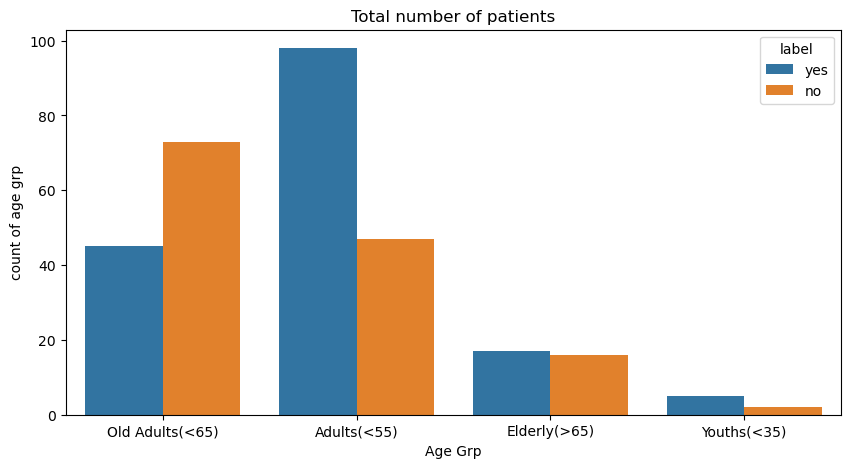

```python
# categorical variable of age bracket vs target/label


print (df['label'].value_counts())

plt.figure(figsize = (10,5))

sns.countplot(x='age_bracket', data=df, hue='label') #label is about whether the person has heart dx or not
plt.xlabel("Age Grp")
plt.ylabel('count of age grp')
plt.title('Total number of patients')
plt.show()
```

```
yes    165
no     138
Name: label, dtype: int64
```

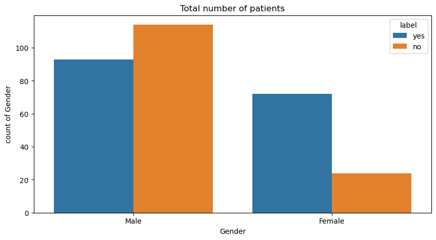

```python
print (df['label'].value_counts())

plt.figure(figsize = (10,5))

sns.countplot(x='gender', data=df, hue='label') #label is about whether the person has heart dx or not
plt.xlabel("Gender")
plt.ylabel('count of Gender')
plt.title('Total number of patients')
plt.show()
```

More females are prone to Heart Dx

```
yes    165
no     138
Name: label, dtype: int64
```

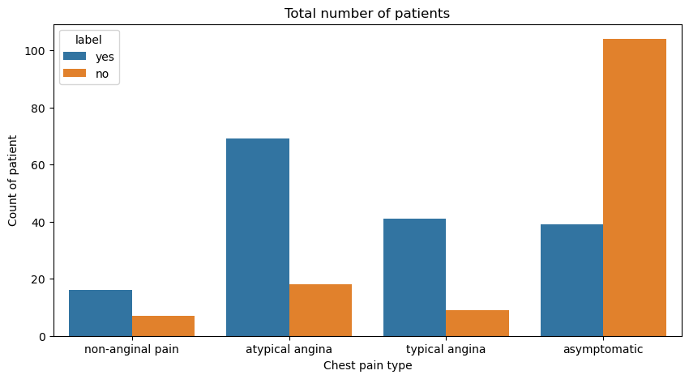

```python
# Which type of chest pain have heart disease?

print (df['label'].value_counts())

plt.figure(figsize = (10,5))

sns.countplot(x='cp_cat', data=df, hue='label') #label is about whether the person has heart dx or not
plt.xlabel("Chest pain type")
plt.ylabel('Count of patient')
plt.title('Total number of patients')
plt.show()
```

```
yes    165
no     138
Name: label, dtype: int64
```

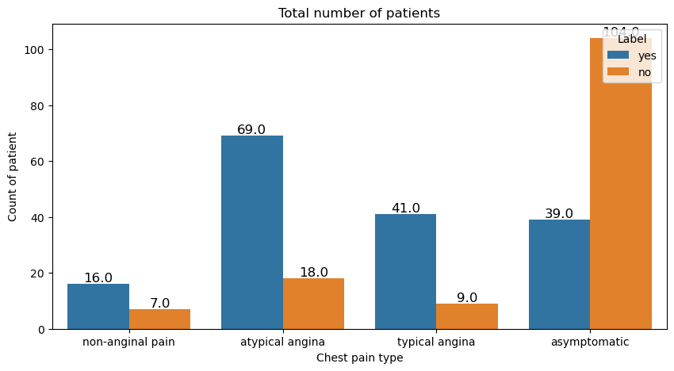

```python
# Print value counts for each label
print(df['label'].value_counts())

plt.figure(figsize=(10, 5))

# Countplot for 'cp_cat' with hue 'label'
ax = sns.countplot(x='cp_cat', data=df, hue='label')

# Label each bar with value count
for p in ax.patches:
    height = p.get_height()
    width = p.get_width()
    x = p.get_x()
    y = p.get_y()
    count = height
    ax.annotate(count, (x + width / 2, y + height), ha='center', va='bottom', fontsize=12)

plt.xlabel("Chest pain type")
plt.ylabel('Count of patient')
plt.title('Total number of patients')
plt.legend(title='Label', loc='upper right')  # Add legend for the 'label' hue
plt.show()
```

atypical and typical angina patient have more heart disease than non angina and asymptomatic patients

```
yes    165
no     138
Name: label, dtype: int64
```

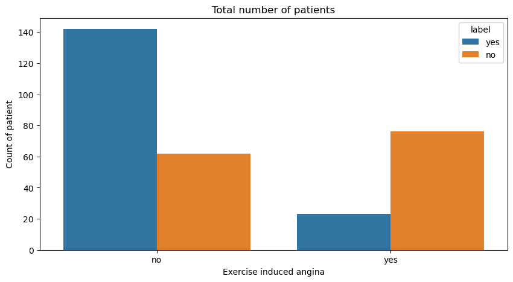

```python
# Excerise induced angina with heart disease
def exinag(exercise_induced_angina):
    if exercise_induced_angina == 1:
        return 'yes'
    else:
        return 'no'
df['exinag'] = df['exercise_induced_angina'].apply(exinag)


print (df['label'].value_counts())

plt.figure(figsize = (10,5))

sns.countplot(x='exinag', data=df, hue='label') #label is about whether the person has heart dx or not
plt.xlabel("Exercise induced angina")
plt.ylabel('Count of patient')
plt.title('Total number of patients')
plt.show()
```

Many of the Targets/labels with no execise induced angina have heart disease while the ones with exercise induced angina have a less number of patients with heart disease

```
yes    165
no     138
Name: label, dtype: int64
```

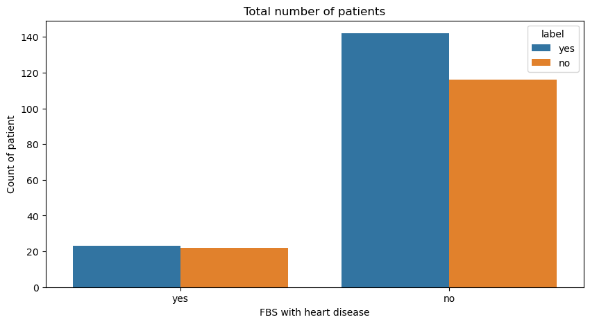

```python
## Using FBS > 120mg/dl to check those with heart disease

def fasting_blood_sugar(FBS):
    if FBS == 1:
        return 'yes'
    else:
        return 'no'
df['fasting_blood_sugar'] = df['FBS'].apply(fasting_blood_sugar)


print (df['label'].value_counts())

plt.figure(figsize = (10,5))

sns.countplot(x='fasting_blood_sugar', data=df, hue='label') #label is about whether the person has heart dx or not
plt.xlabel("FBS with heart disease")
plt.ylabel('Count of patient')
plt.title('Total number of patients')
plt.show()
```

The patients with FBS > 120 mg/dl have no significant difference in the heart diseases. But those with FBS < 120 mg/dl, there is a slight number of them having heart disease

```python
# Check for number of blood vessels and fluroscopy

def fasting_blood_sugar(FBS):
    if FBS == 1:
        return 'yes'
    else:
        return 'no'
df['fasting_blood_sugar'] = df['FBS'].apply(fasting_blood_sugar)


print (df['label'].value_counts())

plt.figure(figsize = (10,5))

sns.countplot(x='fasting_blood_sugar', data=df, hue='label') #label is about whether the person has heart dx or not
plt.xlabel("FBS with heart disease")
plt.ylabel('Count of patient')
plt.title('Total number of patients')
plt.show()
```

[output not shown]

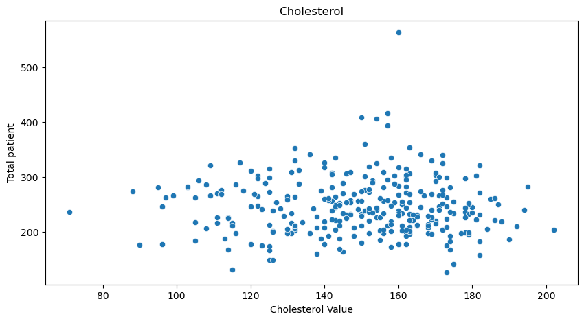

```python
# i want to visualise the age group and ST depression using a scatter plot

plt.figure(figsize=(10,5))

sns.scatterplot( y= 'Cholesterol', x= 'max_hr', data=df)
plt.xlabel('Cholesterol Value')
plt.ylabel('Total patient')
plt.title("Cholesterol")
plt.show()
```

```python
df.head()
```

|  | age | sex | chest_pain_type | systolic_bp | Cholesterol | FBS | rest_ecg | max_hr | exercise_induced_angina | st_depression | st_slope | num_major_vessels | thalassemia | target | age_bracket | gender | cp_cat | label | exinag | fasting_blood_sugar |
| --- | --- | --- | --- | --- | --- | --- | --- | --- | --- | --- | --- | --- | --- | --- | --- | --- | --- | --- | --- | --- |
| 0 | 63 | 1 | 3 | 145 | 233 | 1 | 0 | 150 | 0 | 2.3 | 0 | 0 | 1 | 1 | Old Adults(<65) | Male | non-anginal pain | yes | no | yes |
| 1 | 37 | 1 | 2 | 130 | 250 | 0 | 1 | 187 | 0 | 3.5 | 0 | 0 | 2 | 1 | Adults(<55) | Male | atypical angina | yes | no | no |
| 2 | 41 | 0 | 1 | 130 | 204 | 0 | 0 | 172 | 0 | 1.4 | 2 | 0 | 2 | 1 | Adults(<55) | Female | typical angina | yes | no | no |
| 3 | 56 | 1 | 1 | 120 | 236 | 0 | 1 | 178 | 0 | 0.8 | 2 | 0 | 2 | 1 | Old Adults(<65) | Male | typical angina | yes | no | no |
| 4 | 57 | 0 | 0 | 120 | 354 | 0 | 1 | 163 | 1 | 0.6 | 2 | 0 | 2 | 1 | Old Adults(<65) | Female | asymptomatic | yes | yes | no |

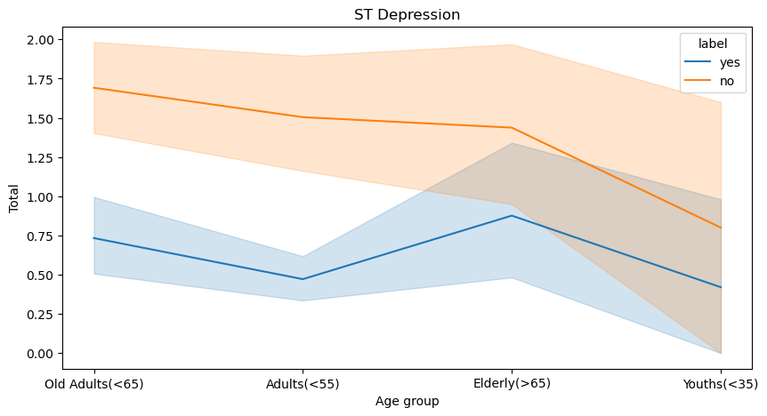

```python
plt.figure(figsize=(10,5))

sns.lineplot( y= 'st_depression', x= 'age_bracket', data=df, hue='label')
plt.xlabel('Age group')
plt.ylabel('Total')
plt.title("ST Depression")
plt.show()
```

### Feature Engineering and Data Prepocessing

```python
df.head(2)
```

|  | age | sex | chest_pain_type | systolic_bp | Cholesterol | FBS | rest_ecg | max_hr | exercise_induced_angina | st_depression | st_slope | num_major_vessels | thalassemia | target | age_bracket | gender | cp_cat | label | exinag | fasting_blood_sugar |
| --- | --- | --- | --- | --- | --- | --- | --- | --- | --- | --- | --- | --- | --- | --- | --- | --- | --- | --- | --- | --- |
| 0 | 63 | 1 | 3 | 145 | 233 | 1 | 0 | 150 | 0 | 2.3 | 0 | 0 | 1 | 1 | Old Adults(<65) | Male | non-anginal pain | yes | no | yes |
| 1 | 37 | 1 | 2 | 130 | 250 | 0 | 1 | 187 | 0 | 3.5 | 0 | 0 | 2 | 1 | Adults(<55) | Male | atypical angina | yes | no | no |

I don't need the age bracket, gender, cp cat, exinag, fasting blood sugar. It is not usefull for my ML.

I will train (using a label) my ML and test it later to see how well it performed. This is for Supervised machine learning

I will remove the column "target" because it is the answer for the ML to find out. The target will be removed after training.

```python
df1 = df[['age', 'sex', 'chest_pain_type', 'systolic_bp', 'Cholesterol', 'FBS', 'rest_ecg', 'max_hr', 'exercise_induced_angina', 'st_depression', 'st_slope', 'num_major_vessels', 'thalassemia']]

label = df[['target']]
```

```python
df1.head(2)
```

|  | age | sex | chest_pain_type | systolic_bp | Cholesterol | FBS | rest_ecg | max_hr | exercise_induced_angina | st_depression | st_slope | num_major_vessels | thalassemia |
| --- | --- | --- | --- | --- | --- | --- | --- | --- | --- | --- | --- | --- | --- |
| 0 | 63 | 1 | 3 | 145 | 233 | 1 | 0 | 150 | 0 | 2.3 | 0 | 0 | 1 |
| 1 | 37 | 1 | 2 | 130 | 250 | 0 | 1 | 187 | 0 | 3.5 | 0 | 0 | 2 |

```python
label.head() #the answer for ML
```

|  | target |
| --- | --- |
| 0 | 1 |
| 1 | 1 |
| 2 | 1 |
| 3 | 1 |
| 4 | 1 |

```python
df1.dtypes # we only work with int or float with ML, Object will not work well with ML
```

```
age                          int64
sex                          int64
chest_pain_type              int64
systolic_bp                  int64
Cholesterol                  int64
FBS                          int64
rest_ecg                     int64
max_hr                       int64
exercise_induced_angina      int64
st_depression              float64
st_slope                     int64
num_major_vessels            int64
thalassemia                  int64
dtype: object
```

```python
# I need to test the data with and without outliers
# using normalisation and MinMaxScaler to make all the values between zero a nd one

scaler = MinMaxScaler()

df1['Scaled_RBP'] = scaler.fit_transform(df1['systolic_bp'].values.reshape(-1, 1))
df1['Scaled_chol'] = scaler.fit_transform(df1['Cholesterol'].values.reshape(-1, 1))
df1['Scaled_thal'] = scaler.fit_transform(df1['thalassemia'].values.reshape(-1, 1))
df1['Scaled_max_hr'] = scaler.fit_transform(df1['max_hr'].values.reshape(-1, 1))

#df1.drop(['systolic_bp', 'thalassemia', 'Cholesterol', 'max_hr'],axis=1, inplace = True)

df1.head()
```

|  | age | sex | chest_pain_type | systolic_bp | Cholesterol | FBS | rest_ecg | max_hr | exercise_induced_angina | st_depression | st_slope | num_major_vessels | thalassemia | Scaled_RBP | Scaled_chol | Scaled_thal | Scaled_max_hr |
| --- | --- | --- | --- | --- | --- | --- | --- | --- | --- | --- | --- | --- | --- | --- | --- | --- | --- |
| 0 | 63 | 1 | 3 | 145 | 233 | 1 | 0 | 150 | 0 | 2.3 | 0 | 0 | 1 | 0.481132 | 0.244292 | 0.333333 | 0.603053 |
| 1 | 37 | 1 | 2 | 130 | 250 | 0 | 1 | 187 | 0 | 3.5 | 0 | 0 | 2 | 0.339623 | 0.283105 | 0.666667 | 0.885496 |
| 2 | 41 | 0 | 1 | 130 | 204 | 0 | 0 | 172 | 0 | 1.4 | 2 | 0 | 2 | 0.339623 | 0.178082 | 0.666667 | 0.770992 |
| 3 | 56 | 1 | 1 | 120 | 236 | 0 | 1 | 178 | 0 | 0.8 | 2 | 0 | 2 | 0.245283 | 0.251142 | 0.666667 | 0.816794 |
| 4 | 57 | 0 | 0 | 120 | 354 | 0 | 1 | 163 | 1 | 0.6 | 2 | 0 | 2 | 0.245283 | 0.520548 | 0.666667 | 0.702290 |

The resting blood pressure, cholesterol, thalassemia and max hr all changed from the regular value to a scaled value. This is essential for the ML algorithym.

I am dropping the unscaled columns because i will not need them for the ML

```python
scaler = MinMaxScaler()

df1['Scaled_RBP'] = scaler.fit_transform(df1['systolic_bp'].values.reshape(-1, 1))
df1['Scaled_chol'] = scaler.fit_transform(df1['Cholesterol'].values.reshape(-1, 1))
df1['Scaled_thal'] = scaler.fit_transform(df1['thalassemia'].values.reshape(-1, 1))
df1['Scaled_max_hr'] = scaler.fit_transform(df1['max_hr'].values.reshape(-1, 1))

df1.drop(['systolic_bp', 'thalassemia', 'Cholesterol', 'max_hr'],axis=1, inplace = True)

df1.head()
```

|  | age | sex | chest_pain_type | FBS | rest_ecg | exercise_induced_angina | st_depression | st_slope | num_major_vessels | Scaled_RBP | Scaled_chol | Scaled_thal | Scaled_max_hr |
| --- | --- | --- | --- | --- | --- | --- | --- | --- | --- | --- | --- | --- | --- |
| 0 | 63 | 1 | 3 | 1 | 0 | 0 | 2.3 | 0 | 0 | 0.481132 | 0.244292 | 0.333333 | 0.603053 |
| 1 | 37 | 1 | 2 | 0 | 1 | 0 | 3.5 | 0 | 0 | 0.339623 | 0.283105 | 0.666667 | 0.885496 |
| 2 | 41 | 0 | 1 | 0 | 0 | 0 | 1.4 | 2 | 0 | 0.339623 | 0.178082 | 0.666667 | 0.770992 |
| 3 | 56 | 1 | 1 | 0 | 1 | 0 | 0.8 | 2 | 0 | 0.245283 | 0.251142 | 0.666667 | 0.816794 |
| 4 | 57 | 0 | 0 | 0 | 1 | 1 | 0.6 | 2 | 0 | 0.245283 | 0.520548 | 0.666667 | 0.702290 |

I have dropped four columns here. Check above

# Machine Learning

```python
# Split the data set into training and testing sets - X = Questions, y = Answers

# xtrain and y train go together, x test and y test go together

# X_train are practice questions, Y train is your answer to the practice question

# X_test is the exam for ML, and y_test is the answer to cross check

X_train, X_test, y_train, y_test, = train_test_split(df1, label, test_size = 0.2, random_state=42)
```

```python
df1.shape # both label and df1 have same row
```

```
(303, 13)
```

```python
label.shape
```

```
(303, 1)
```

```python
X_train # Practise question for ML
```

|  | age | sex | chest_pain_type | FBS | rest_ecg | exercise_induced_angina | st_depression | st_slope | num_major_vessels | Scaled_RBP | Scaled_chol | Scaled_thal | Scaled_max_hr |
| --- | --- | --- | --- | --- | --- | --- | --- | --- | --- | --- | --- | --- | --- |
| 132 | 42 | 1 | 1 | 0 | 1 | 0 | 0.0 | 2 | 0 | 0.245283 | 0.385845 | 0.666667 | 0.694656 |
| 202 | 58 | 1 | 0 | 0 | 0 | 1 | 0.8 | 2 | 0 | 0.528302 | 0.328767 | 1.000000 | 0.305344 |
| 196 | 46 | 1 | 2 | 0 | 1 | 0 | 3.6 | 1 | 0 | 0.528302 | 0.239726 | 0.666667 | 0.580153 |
| 75 | 55 | 0 | 1 | 0 | 0 | 0 | 1.4 | 1 | 0 | 0.386792 | 0.283105 | 0.666667 | 0.687023 |
| 176 | 60 | 1 | 0 | 1 | 1 | 1 | 1.4 | 2 | 2 | 0.216981 | 0.237443 | 1.000000 | 0.679389 |
| ... | ... | ... | ... | ... | ... | ... | ... | ... | ... | ... | ... | ... | ... |
| 188 | 50 | 1 | 2 | 0 | 1 | 0 | 0.6 | 1 | 1 | 0.433962 | 0.244292 | 1.000000 | 0.702290 |
| 71 | 51 | 1 | 2 | 0 | 1 | 1 | 0.0 | 2 | 1 | 0.000000 | 0.230594 | 1.000000 | 0.633588 |
| 106 | 69 | 1 | 3 | 1 | 0 | 0 | 0.1 | 1 | 1 | 0.622642 | 0.246575 | 0.666667 | 0.458015 |
| 270 | 46 | 1 | 0 | 0 | 0 | 0 | 0.8 | 2 | 0 | 0.245283 | 0.280822 | 1.000000 | 0.557252 |
| 102 | 63 | 0 | 1 | 0 | 1 | 0 | 0.0 | 2 | 2 | 0.433962 | 0.157534 | 0.666667 | 0.824427 |

242 rows × 13 columns

```python
y_train.head(3)
```

|  | target |
| --- | --- |
| 132 | 1 |
| 202 | 0 |
| 196 | 0 |

```python
 X_test.head(3)
```

|  | age | sex | chest_pain_type | FBS | rest_ecg | exercise_induced_angina | st_depression | st_slope | num_major_vessels | Scaled_RBP | Scaled_chol | Scaled_thal | Scaled_max_hr |
| --- | --- | --- | --- | --- | --- | --- | --- | --- | --- | --- | --- | --- | --- |
| 179 | 57 | 1 | 0 | 0 | 0 | 1 | 0.6 | 1 | 1 | 0.528302 | 0.342466 | 0.333333 | 0.312977 |
| 228 | 59 | 1 | 3 | 0 | 0 | 0 | 0.2 | 1 | 0 | 0.716981 | 0.369863 | 1.000000 | 0.671756 |
| 111 | 57 | 1 | 2 | 1 | 1 | 0 | 0.2 | 2 | 1 | 0.528302 | 0.000000 | 1.000000 | 0.778626 |

```python
y_test.head(3)
```

|  | target |
| --- | --- |
| 179 | 0 |
| 228 | 0 |
| 111 | 1 |

```python
# Model Building

# Logistic Regression

logreg = LogisticRegression()

logreg.fit(X_train, y_train) # machine learning code for the ML Practice/training

ly_pred = logreg.predict(X_test) # ML code for the ML to predict

print ('Logistic Regression')
print ('Accurracy:', accuracy_score(y_test, ly_pred))
print ('Precision:', precision_score(y_test, ly_pred))
print ('Recall:', recall_score(y_test, ly_pred))
print ('F1-score:', f1_score(y_test, ly_pred))
print ('AUC-ROC:', roc_auc_score(y_test, ly_pred))
```

```
Logistic Regression
Accurracy: 0.8688524590163934
Precision: 0.875
Recall: 0.875
F1-score: 0.875
AUC-ROC: 0.8685344827586206
```

```python
X_test #the table that ML predicted on
```

|  | age | sex | chest_pain_type | FBS | rest_ecg | exercise_induced_angina | st_depression | st_slope | num_major_vessels | Scaled_RBP | Scaled_chol | Scaled_thal | Scaled_max_hr |
| --- | --- | --- | --- | --- | --- | --- | --- | --- | --- | --- | --- | --- | --- |
| 179 | 57 | 1 | 0 | 0 | 0 | 1 | 0.6 | 1 | 1 | 0.528302 | 0.342466 | 0.333333 | 0.312977 |
| 228 | 59 | 1 | 3 | 0 | 0 | 0 | 0.2 | 1 | 0 | 0.716981 | 0.369863 | 1.000000 | 0.671756 |
| 111 | 57 | 1 | 2 | 1 | 1 | 0 | 0.2 | 2 | 1 | 0.528302 | 0.000000 | 1.000000 | 0.778626 |
| 246 | 56 | 0 | 0 | 0 | 0 | 1 | 1.9 | 1 | 2 | 0.377358 | 0.646119 | 1.000000 | 0.603053 |
| 60 | 71 | 0 | 2 | 1 | 0 | 0 | 0.0 | 2 | 1 | 0.150943 | 0.317352 | 0.666667 | 0.450382 |
| ... | ... | ... | ... | ... | ... | ... | ... | ... | ... | ... | ... | ... | ... |
| 249 | 69 | 1 | 2 | 0 | 0 | 0 | 2.0 | 1 | 3 | 0.433962 | 0.292237 | 1.000000 | 0.572519 |
| 104 | 50 | 1 | 2 | 0 | 1 | 0 | 0.0 | 2 | 0 | 0.330189 | 0.159817 | 0.666667 | 0.702290 |
| 300 | 68 | 1 | 0 | 1 | 1 | 0 | 3.4 | 1 | 2 | 0.471698 | 0.152968 | 1.000000 | 0.534351 |
| 193 | 60 | 1 | 0 | 0 | 0 | 1 | 2.8 | 1 | 2 | 0.481132 | 0.356164 | 1.000000 | 0.541985 |
| 184 | 50 | 1 | 0 | 0 | 0 | 0 | 2.6 | 1 | 0 | 0.528302 | 0.267123 | 1.000000 | 0.435115 |

61 rows × 13 columns

```python
ly_pred #the predition of X-test (the Machine learning Algorithm) for the target whether they have Heart disease or not
```

```
array([0, 1, 1, 0, 1, 1, 1, 0, 0, 1, 1, 0, 1, 0, 1, 1, 1, 0, 0, 0, 1, 0,
       0, 1, 1, 1, 1, 0, 0, 1, 0, 0, 0, 0, 1, 0, 1, 1, 1, 1, 1, 1, 1, 1,
       1, 0, 1, 1, 0, 0, 0, 0, 1, 1, 0, 0, 0, 1, 0, 0, 0], dtype=int64)
```

```python
y_test
# the true answer that we have on the table where we can compare our "ly_pred" prediction on to check the accuracy or precision
```

|  | target |
| --- | --- |
| 179 | 0 |
| 228 | 0 |
| 111 | 1 |
| 246 | 0 |
| 60 | 1 |
| ... | ... |
| 249 | 0 |
| 104 | 1 |
| 300 | 0 |
| 193 | 0 |
| 184 | 0 |

61 rows × 1 columns

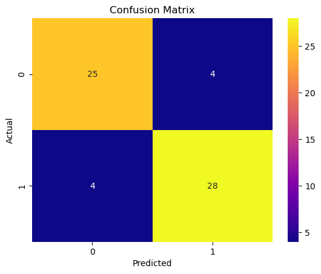

```python
# I am using the Confusion Matrix for the next for Logistic Regression in ML

lcm = confusion_matrix(y_test, ly_pred) # l c m logistic confussion matrix

# to visualise the confusion matrix

sns.heatmap(lcm, annot = True, cmap='plasma', fmt='g')
plt.xlabel('Predicted')
plt.ylabel('Actual')
plt.title('Confusion Matrix')
plt.show();
```

Accuracy: (TP + TN) / (TP + TN + FP + FN), the proportion of correctly predicted instances among all instances.

Precision: TP / (TP + FP), the proportion of true positive predictions among all positive predictions made by the model.

Recall (Sensitivity or True Positive Rate): TP / (TP + FN), the proportion of actual positive instances that were correctly predicted by the model.

Specificity: TN / (TN + FP), the proportion of actual negative instances that were correctly predicted by the model.

F1-score: 2 *(Precision* Recall) / (Precision + Recall), a balanced measure that combines precision and recall.

ROC curve and AUC-ROC: A graphical representation of the model's trade-off between true positive rate and false positive rate for different threshold values.

```python
# I want to try the random forest modeling for prediction

# Random Forest Classifier


rfc = RandomForestClassifier()
rfc.fit(X_train, y_train)
rfy_pred = rfc.predict(X_test)

print ('Logistic Regression')
print ('Accurracy:', accuracy_score(y_test, ly_pred))
print ('Precision:', precision_score(y_test, ly_pred))
print ('Recall:', recall_score(y_test, ly_pred))
print ('F1-score:', f1_score(y_test, ly_pred))
print ('AUC-ROC:', roc_auc_score(y_test, ly_pred))
```

```
Logistic Regression
Accurracy: 0.8688524590163934
Precision: 0.875
Recall: 0.875
F1-score: 0.875
AUC-ROC: 0.8685344827586206
```

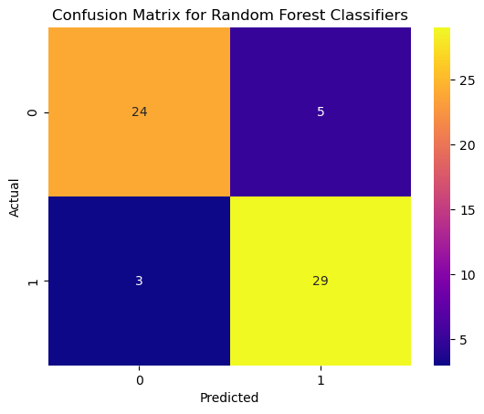

```python
# Creating a confusion Matrix for Random Forest

rcm = confusion_matrix(y_test, rfy_pred) # r c m  Random Forest Classifier

# to visualise the confusion matrix

sns.heatmap(rcm, annot = True, cmap='plasma', fmt='g')
plt.xlabel('Predicted')
plt.ylabel('Actual')
plt.title('Confusion Matrix for Random Forest Classifiers')
plt.show();
```

Here, Random Forest predicted 29 correctly TO have Heart disease

Here, RANDOM FOREST predicted 5 TO HAVE Heart disease, BUT in reality, they do not have. False Positives

Here, RANDOM FOREST PREDICTED 3 NOT TO HAVE HEART DISEASE, BUT IN REALITY, THEY HAVE. FALSE NEGATIVES

It is highly CRITICAL TO CONSIDER FALSE NEGATIVES. I WANT TO MINIMISE FALSE NEGATIVES AS MUCH AS POSSIBLE. THE ERROR ON FN COULD BE DEVASTATING

```python
# Deploying several machine learning algorithym
# eight of the ML
# Classifiers


classifiers = [[XGBClassifier(), 'XGB Classifier'],
              [RandomForestClassifier(), 'Random Forest'],
              [KNeighborsClassifier(), 'K-Nearest Neighbors'],
              [SGDClassifier(), 'SGD Classifier'],
              [SVC(), 'SVC'],
              [GaussianNB(), 'Naive Bayes'],
              [DecisionTreeClassifier(random_state = 42), 'Decision Tree'],
              [LogisticRegression(), 'Logistic Regression']
              ]
```

```python
classifiers
```

```
[[XGBClassifier(base_score=None, booster=None, callbacks=None,
                colsample_bylevel=None, colsample_bynode=None,
                colsample_bytree=None, early_stopping_rounds=None,
                enable_categorical=False, eval_metric=None, feature_types=None,
                gamma=None, gpu_id=None, grow_policy=None, importance_type=None,
                interaction_constraints=None, learning_rate=None, max_bin=None,
                max_cat_threshold=None, max_cat_to_onehot=None,
                max_delta_step=None, max_depth=None, max_leaves=None,
                min_child_weight=None, missing=nan, monotone_constraints=None,
                n_estimators=100, n_jobs=None, num_parallel_tree=None,
                predictor=None, random_state=None, ...),
  'XGB Classifier'],
 [RandomForestClassifier(), 'Random Forest'],
 [KNeighborsClassifier(), 'K-Nearest Neighbors'],
 [SGDClassifier(), 'SGD Classifier'],
 [SVC(), 'SVC'],
 [GaussianNB(), 'Naive Bayes'],
 [DecisionTreeClassifier(random_state=42), 'Decision Tree'],
 [LogisticRegression(), 'Logistic Regression']]
```

```python
acc_list = {}
precision_list = {}
recall_list = {}
roc_list = {}


for classifier in classifiers:
    model = classifier[0]
    model.fit(X_train, y_train) # to train
    model_name = classifier[1]

    pred = model.predict(X_test)

    a_score = accuracy_score(y_test, pred) # to test and predict
    p_score = precision_score(y_test, pred)
    r_score = recall_score(y_test, pred)
    roc_score = roc_auc_score(y_test, pred)

    acc_list[model_name] = ([str(round(a_score*100, 2)) + '%']) # to convert the answer into a percentage
    precision_list[model_name] = ([str(round(p_score*100, 2)) + '%'])
    recall_list[model_name] = ([str(round(r_score*100, 2)) + '%'])
    roc_list[model_name] = ([str(round(roc_score*100, 2)) + '%'])

    if model_name != classifiers[-1][1]:
         print ('')
```

```python
acc_list # This is showing the accuracy list for all the classifiers. Note the classifier with the highest accuracy
```

```
{'XGB Classifier': ['83.61%'],
 'Random Forest': ['86.89%'],
 'K-Nearest Neighbors': ['75.41%'],
 'SGD Classifier': ['72.13%'],
 'SVC': ['65.57%'],
 'Naive Bayes': ['86.89%'],
 'Decision Tree': ['85.25%'],
 'Logistic Regression': ['86.89%']}
```

###### Naive Bayes has 86.9 and 90, Decison Tree with 85 and 92.5, and logistic regression with 86.9 and 87.5 of accuracy and precision respectively.

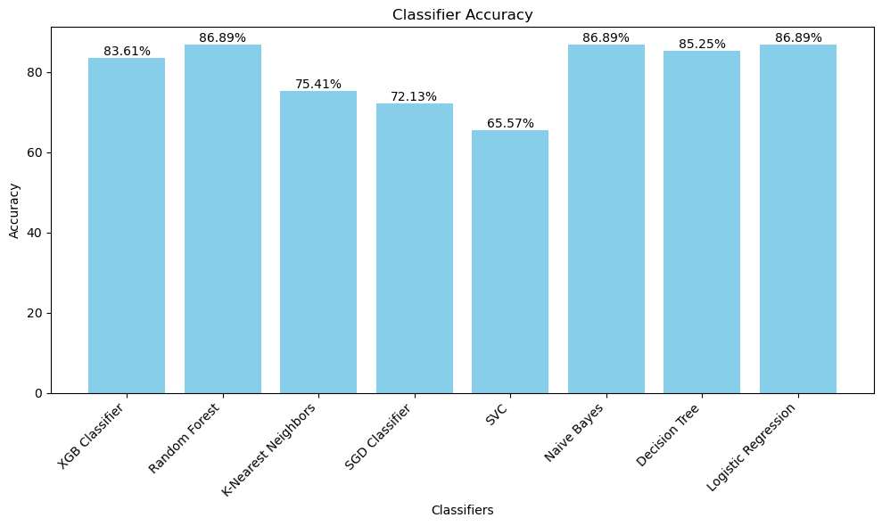

```python
# bar chat visualisation

data = {
    'XGB Classifier': ['83.61%'],
    'Random Forest': ['86.89%'],
    'K-Nearest Neighbors': ['75.41%'],
    'SGD Classifier': ['72.13%'],
    'SVC': ['65.57%'],
    'Naive Bayes': ['86.89%'],
    'Decision Tree': ['85.25%'],
    'Logistic Regression': ['86.89%']
}

# Extract percentages as floating-point numbers
percentages = [float(value[0].replace('%', '')) for value in data.values()]

# Extract the classifiers (labels) from the keys
classifiers = list(data.keys())

# Create a bar chart
plt.figure(figsize=(10, 6))
plt.bar(classifiers, percentages, color='skyblue')

# Add percentage values above each bar
for i, value in enumerate(percentages):
    plt.text(i, value, f'{value:.2f}%', ha='center', va='bottom')

# Add a title and labels
plt.xlabel('Classifiers')
plt.ylabel('Accuracy')
plt.title('Classifier Accuracy')

# Rotate the x-axis labels for better readability
plt.xticks(rotation=45, ha='right')

# Display the bar chart
plt.tight_layout()
plt.show()
```

```python
# convert the accuracy list into a table for easy visualistion
print ('Accuracy Score')
s1 = pd.DataFrame(acc_list) # s1 is just to assign the acc_list. No meaning attached to s1
s1.head()
```

```
Accuracy Score
```

|  | XGB Classifier | Random Forest | K-Nearest Neighbors | SGD Classifier | SVC | Naive Bayes | Decision Tree | Logistic Regression |
| --- | --- | --- | --- | --- | --- | --- | --- | --- |
| 0 | 83.61% | 86.89% | 75.41% | 72.13% | 65.57% | 86.89% | 85.25% | 86.89% |

```python
print('Precision Score')

s2 = pd.DataFrame(precision_list)
s2.head()
```

```
Precision Score
```

|  | XGB Classifier | Random Forest | K-Nearest Neighbors | SGD Classifier | SVC | Naive Bayes | Decision Tree | Logistic Regression |
| --- | --- | --- | --- | --- | --- | --- | --- | --- |
| 0 | 86.67% | 85.29% | 79.31% | 85.71% | 65.71% | 90.0% | 92.59% | 87.5% |

```python
print ('Recall')

s3 = pd.DataFrame(recall_list) # s1 is just to assign the recall_list. No meaning attached to s1
s3.head()
```

```
Recall
```

|  | XGB Classifier | Random Forest | K-Nearest Neighbors | SGD Classifier | SVC | Naive Bayes | Decision Tree | Logistic Regression |
| --- | --- | --- | --- | --- | --- | --- | --- | --- |
| 0 | 81.25% | 90.62% | 71.88% | 56.25% | 71.88% | 84.38% | 78.12% | 87.5% |

```python
print('ROC Score')

s4 = pd.DataFrame(roc_list)
s4.head()
```

```
ROC Score
```

|  | XGB Classifier | Random Forest | K-Nearest Neighbors | SGD Classifier | SVC | Naive Bayes | Decision Tree | Logistic Regression |
| --- | --- | --- | --- | --- | --- | --- | --- | --- |
| 0 | 83.73% | 86.69% | 75.59% | 72.95% | 65.25% | 87.02% | 85.61% | 86.85% |

# Overall, RandomForestClassifiers has the least False Negatives,

# Using the Confudiion Heat Map,

- FN: Logistic regression has 4 patients declared as No heart Dx, but in reality have heart Dx, Random Forest has 3, XGB has 6, KNeigh has 9, SDG has 4, Gaussian (Naive Bayes) has 5, and Decision Tree has 8
- TP: Logistic regression has 28 patients declared as heart Dx, and in reality have heart Dx, Random Forest has 29, XGB has 26, KNeigh has 23, SDG has 28, Gaussian (Naive Bayes) has 27, and Decision Tree has 24

Across board, Logistic regression seems to have a relatively high accuracy, precision, recall, and roc

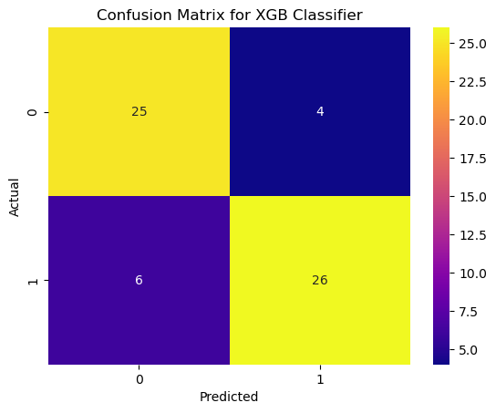

```python
# Creating a confusion Matrix for Random Forest

xgb = XGBClassifier()
xgb.fit(X_train, y_train)
xgb_pred = xgb.predict(X_test)

xgb = confusion_matrix(y_test, xgb_pred) # l c m logistic confussion matrix

# to visualise the confusion matrix

sns.heatmap(xgb, annot = True, cmap='plasma', fmt='g')
plt.xlabel('Predicted')
plt.ylabel('Actual')
plt.title('Confusion Matrix for XGB Classifier')
plt.show();
```

FN for XGB Classifier here is huge. saying 6 persons do not have Heart Disease, but in the real sense, they do have.

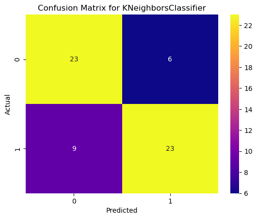

```python
kn = KNeighborsClassifier()
kn.fit(X_train, y_train)
kn_pred = kn.predict(X_test)

kne = confusion_matrix(y_test, kn_pred) #  KNeighborsClassifier()

# to visualise the confusion matrix

sns.heatmap(kne, annot = True, cmap='plasma', fmt='g')
plt.xlabel('Predicted')
plt.ylabel('Actual')
plt.title('Confusion Matrix for KNeighborsClassifier')
plt.show();
```

FN for KNeighborsClassifier is even higher

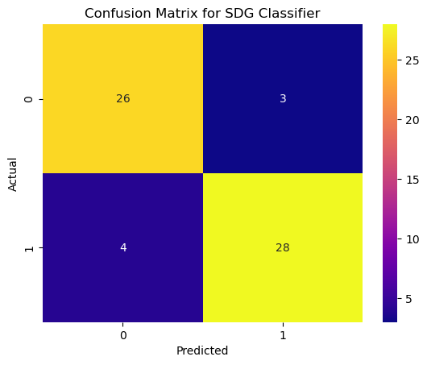

```python
sdg = SGDClassifier()
sdg.fit(X_train, y_train)
sdgs_pred = sdg.predict(X_test)

sd = confusion_matrix(y_test, sdgs_pred) #  SDG Classifier

# to visualise the confusion matrix

sns.heatmap(sd, annot = True, cmap='plasma', fmt='g')
plt.xlabel('Predicted')
plt.ylabel('Actual')
plt.title('Confusion Matrix for SDG Classifier')
plt.show();
```

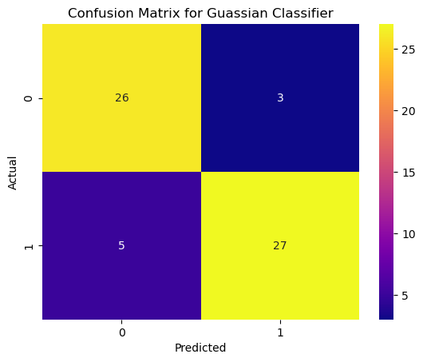

```python
gau = GaussianNB()
gau.fit(X_train, y_train)
ga_pred = gau.predict(X_test)

g = confusion_matrix(y_test, ga_pred) #  SDG Classifier

# to visualise the confusion matrix

sns.heatmap(g, annot = True, cmap='plasma', fmt='g')
plt.xlabel('Predicted')
plt.ylabel('Actual')
plt.title('Confusion Matrix for Guassian Classifier')
plt.show();
```

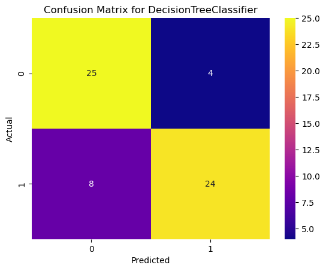

```python
dtc = DecisionTreeClassifier()
dtc.fit(X_train, y_train)
dtc_pred = dtc.predict(X_test)

dt = confusion_matrix(y_test, dtc_pred) #  SDG Classifier

# to visualise the confusion matrix

sns.heatmap(dt, annot = True, cmap='plasma', fmt='g')
plt.xlabel('Predicted')
plt.ylabel('Actual')
plt.title('Confusion Matrix for DecisionTreeClassifier')
plt.show();
```

```python
classifiers = [[XGBClassifier(), 'XGB Classifier'],
              [RandomForestClassifier(), 'Random Forest'],
              [KNeighborsClassifier(), 'K-Nearest Neighbors'],
              [SGDClassifier(), 'SGD Classifier'],
              [SVC(), 'SVC'],
              [GaussianNB(), 'Naive Bayes'],
              [DecisionTreeClassifier(random_state = 42), 'Decision Tree'],
              [LogisticRegression(), 'Logistic Regression']
              ]
```